# Image Compression Project

2026-09-24

## PCA Rank Approximation Function

**Below is the rank approximation function I created for the provided images.**

```r
library(readr)
img1 <- read_csv("image1.csv")
img1 <- data.matrix(img1)
rank_k_pca_approx <- function(img, k) {

  n <- nrow(img)
  p <- ncol(img)
  k <- min(k, n, p)

  pca <- prcomp(img, center = TRUE, scale. = FALSE)

  scores_k   <- pca$x[, 1:k, drop = FALSE]
  loadings_k <- pca$rotation[, 1:k, drop = FALSE]

  approx <- scores_k %*% t(loadings_k)
  approx <- sweep(approx, 2, pca$center, "+")

  error <- norm(img - approx, type = "F")

  list(approximation = approx, error = error)
}

##result <- rank_k_pca_approx(img1, k = 10)
##plot(result$approximation)
```

## IMAGE 1

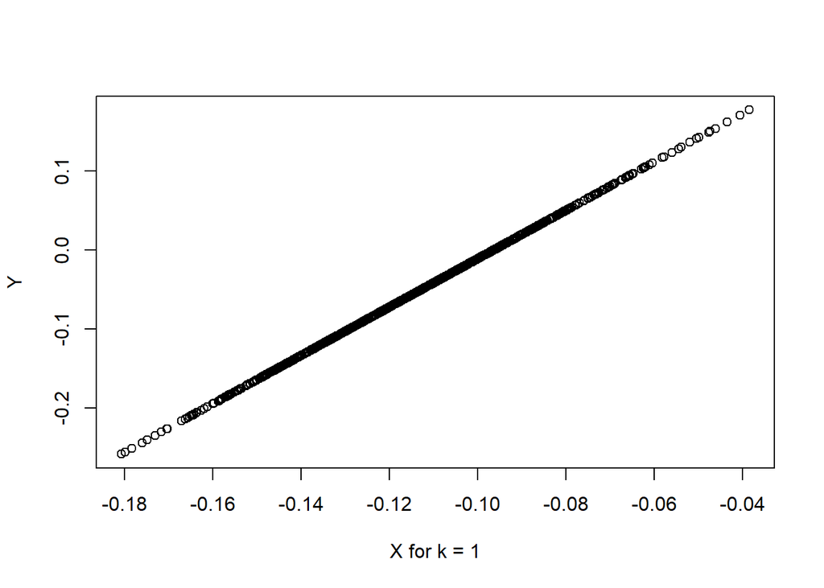

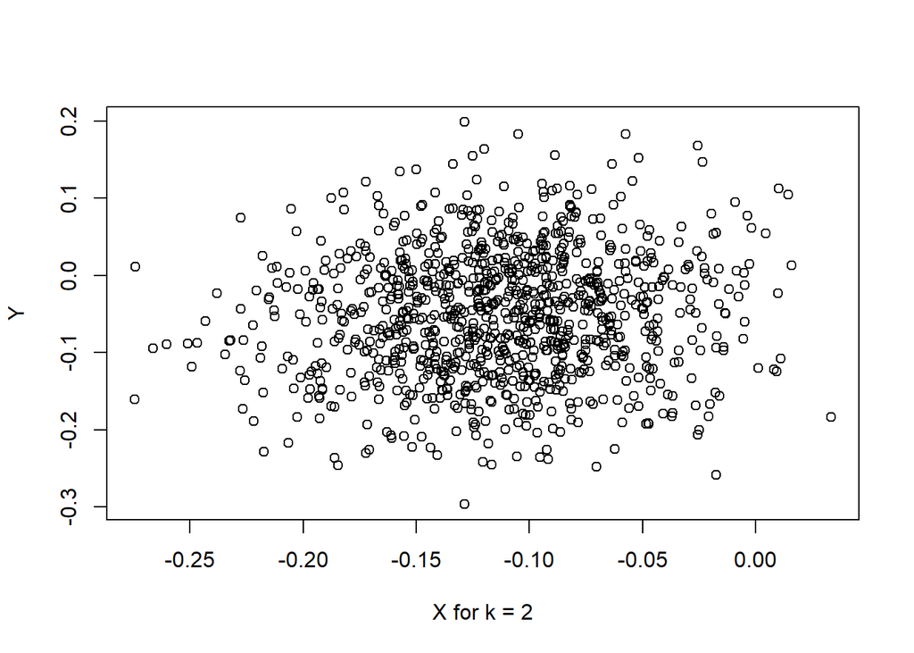

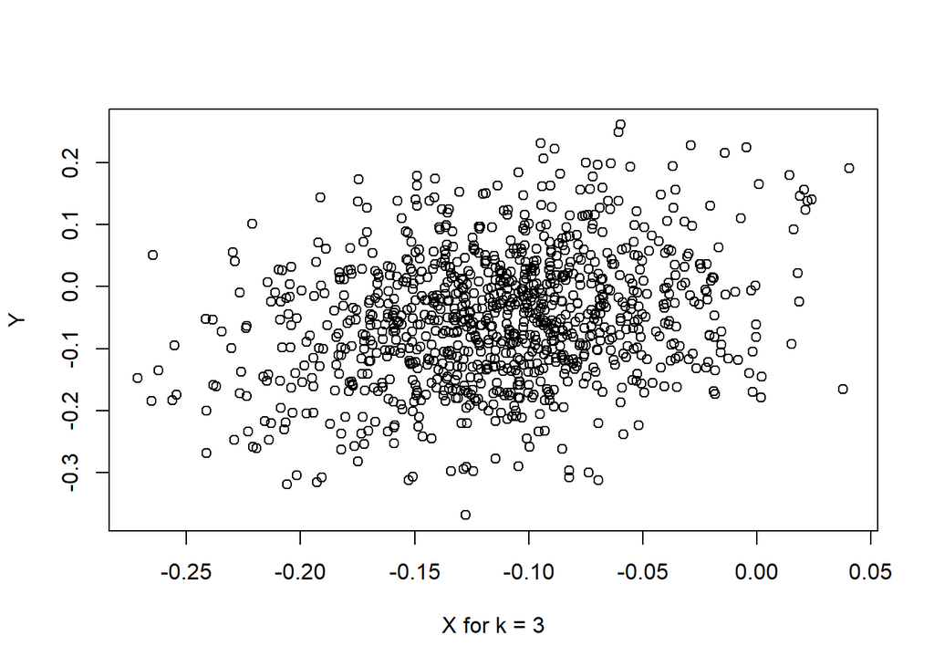

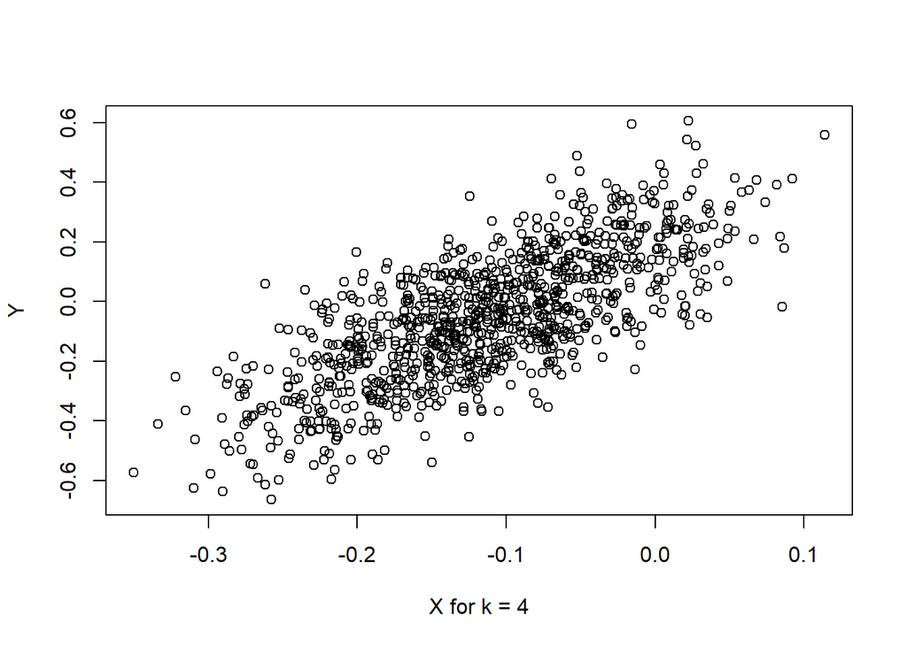

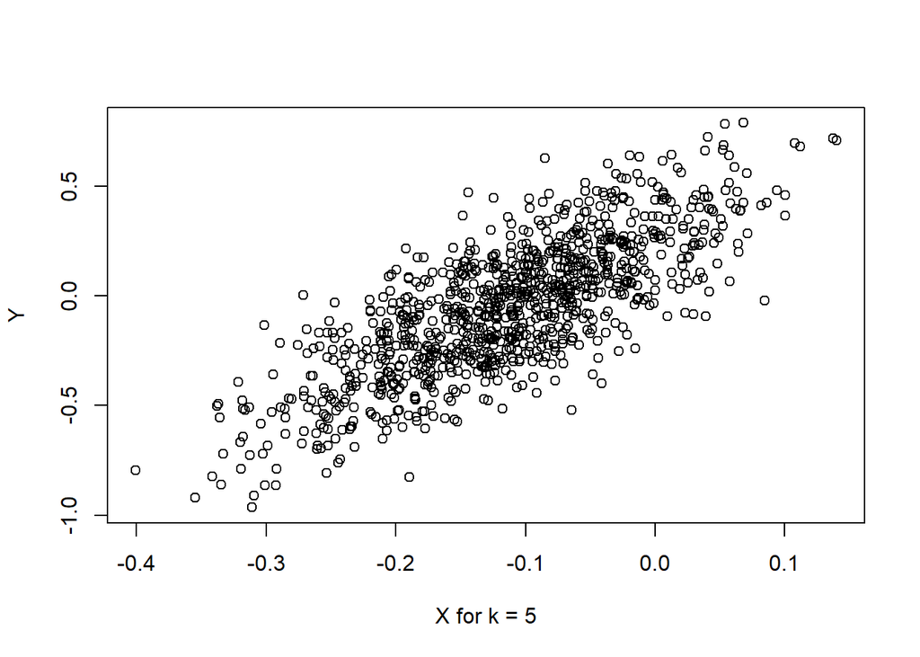

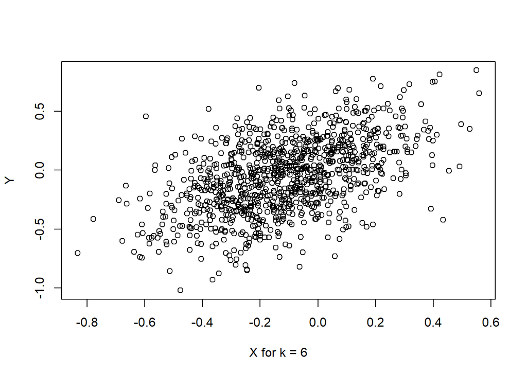

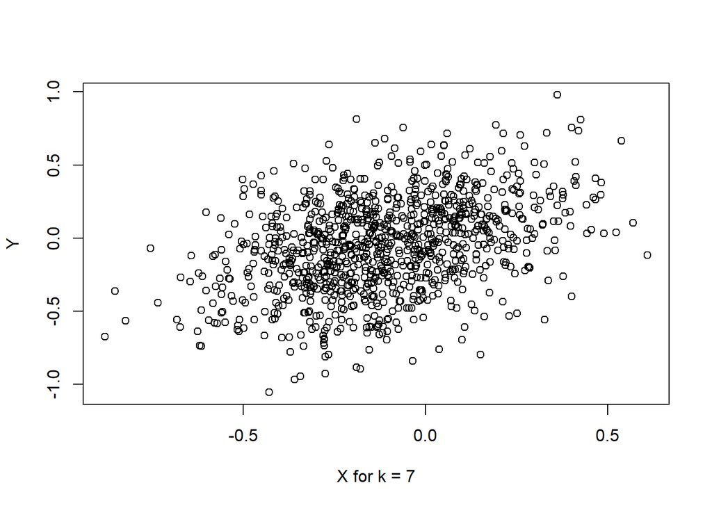

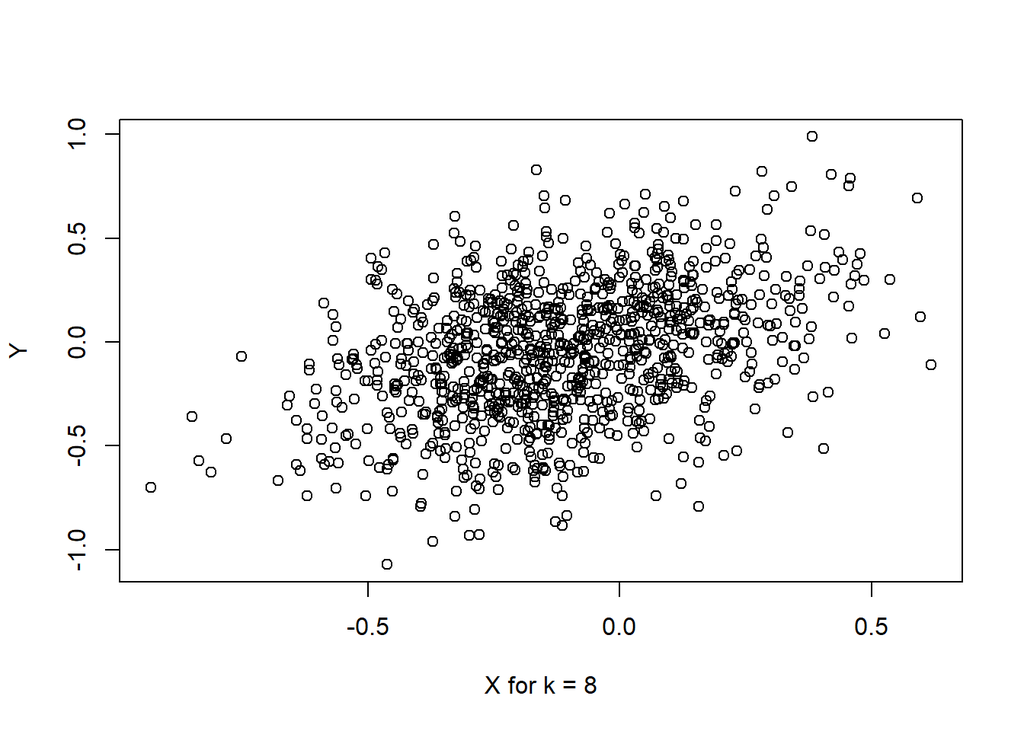

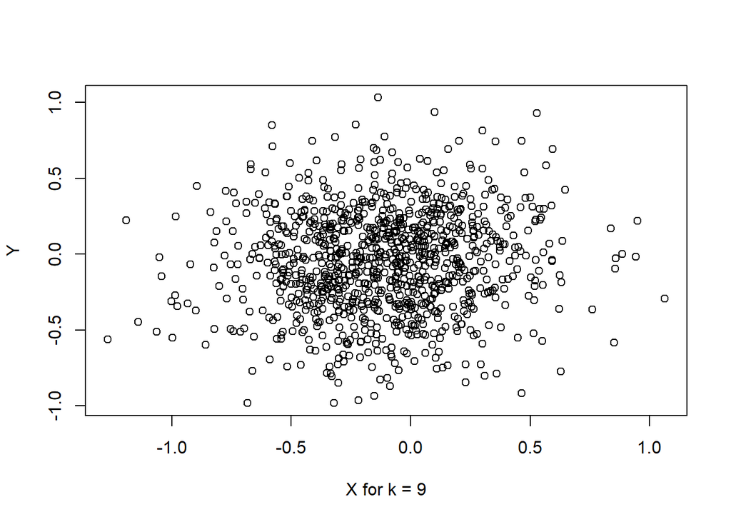

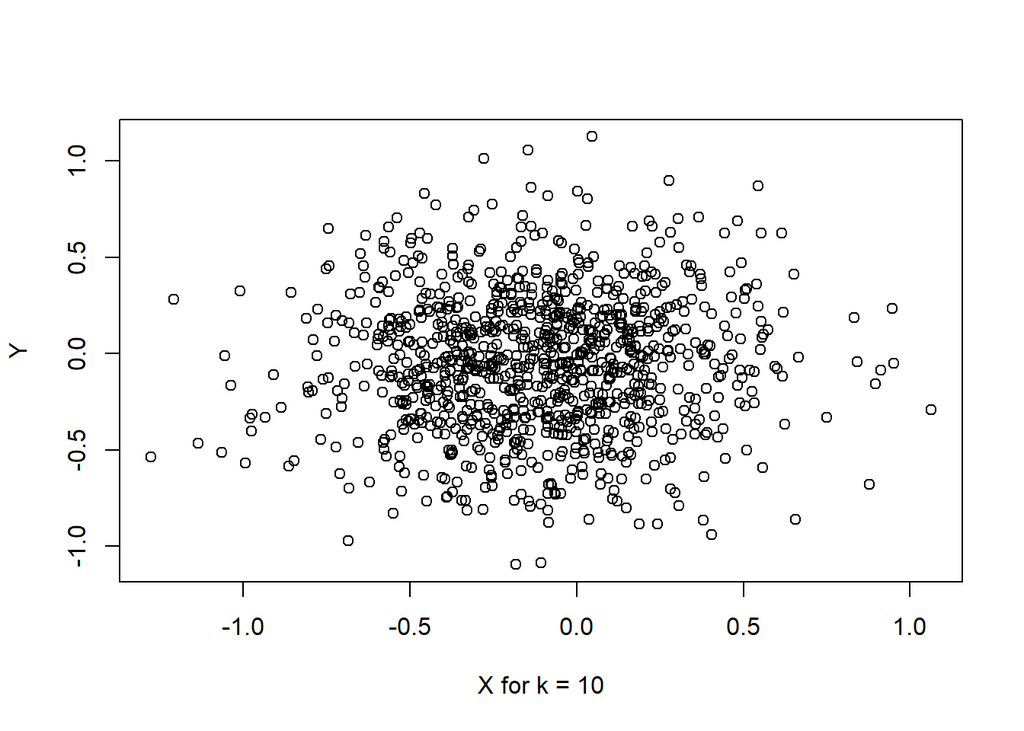

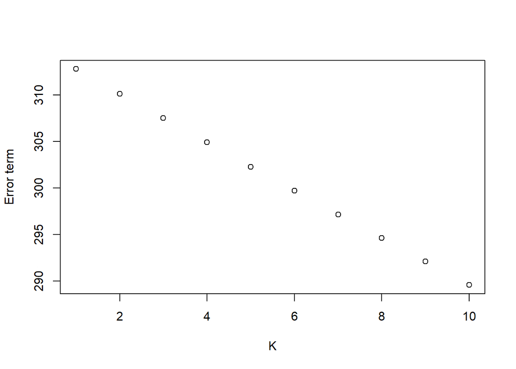

**Below is the plot of the first eigenvector, followed by a plot of the first PC score**

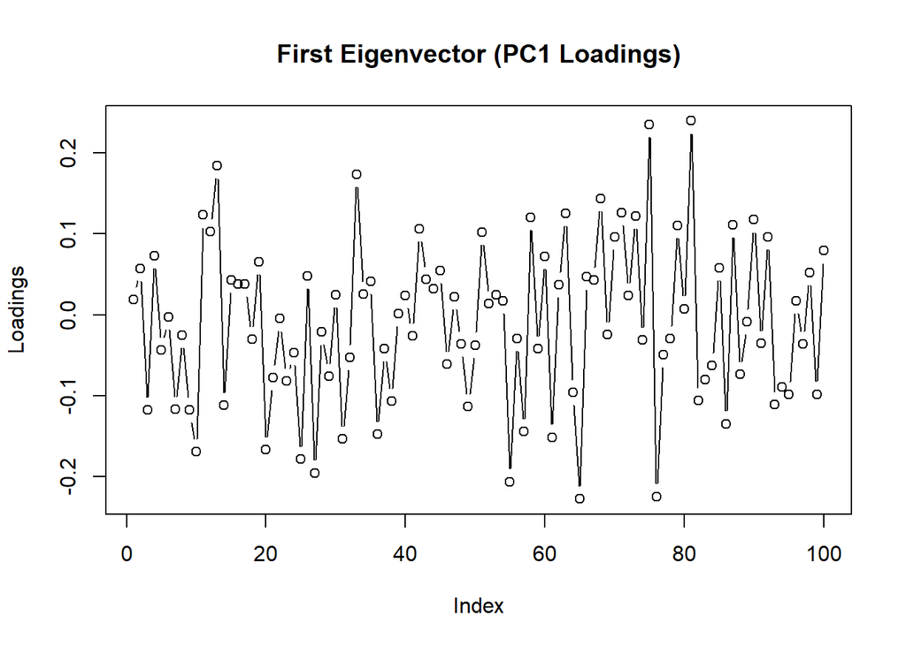

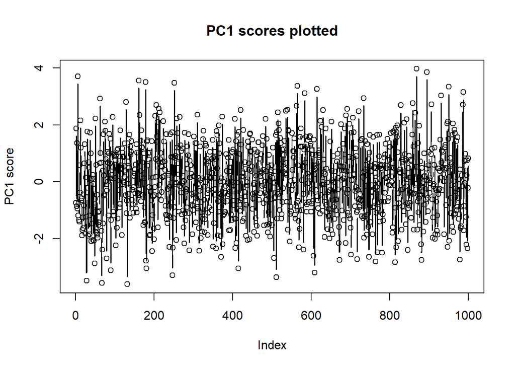

**Interpretation of PC1 scores and Eigenvector plots**

**For the PC1 score plot, each number represents how far a feature projects in the new direction. In terms of the Eigenvectors plot, each index is how much a particular variable contributes to the principal component itself.**

## Image 2

**Here are the rank approximations for the second image, as well as the plot of error terms and k values.**

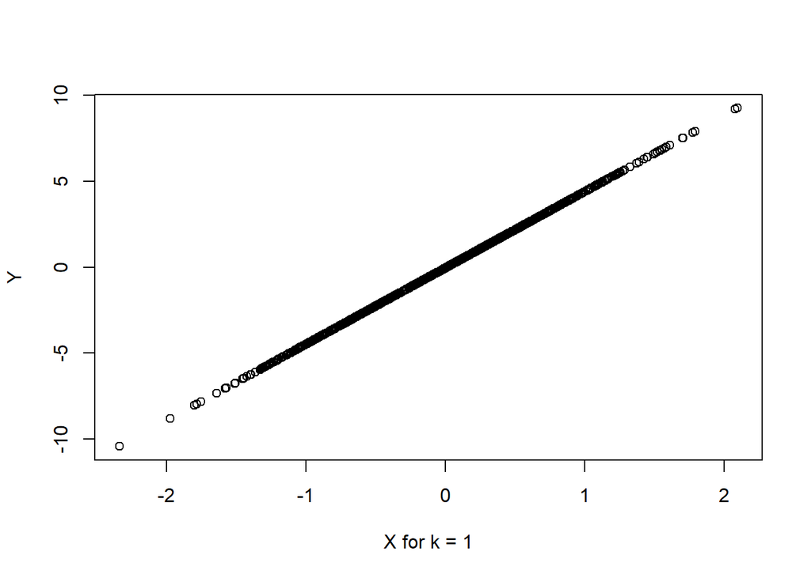

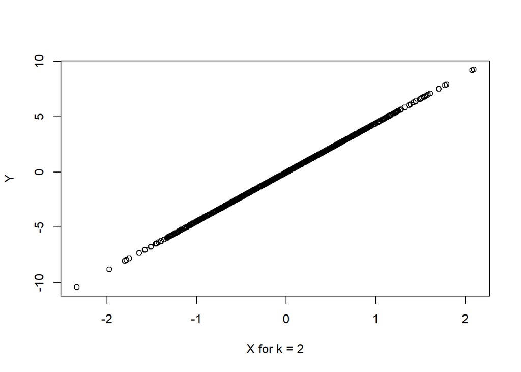

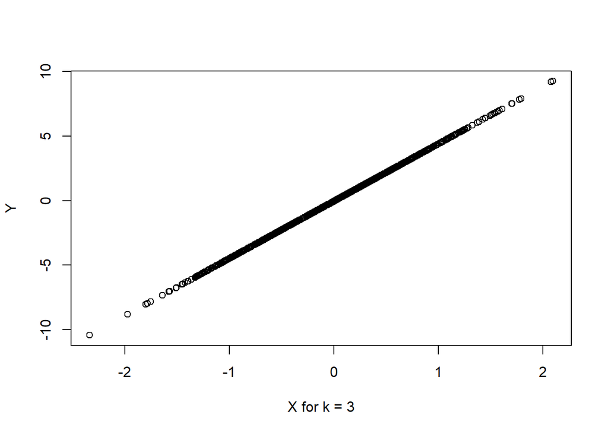

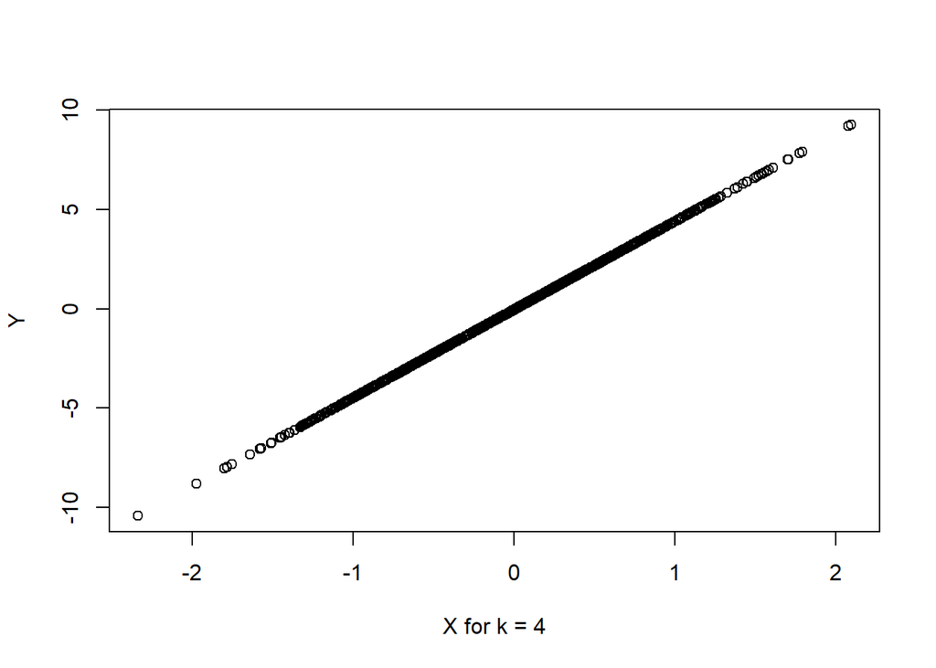

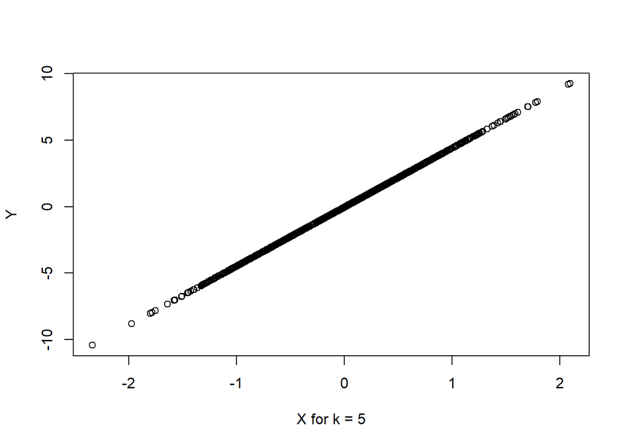

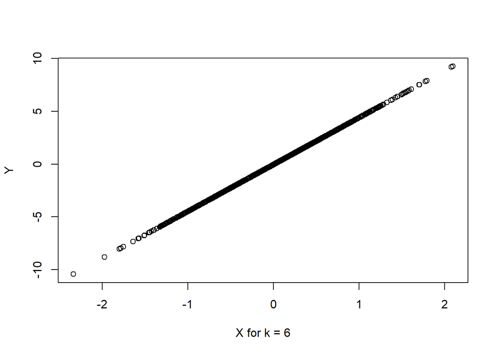

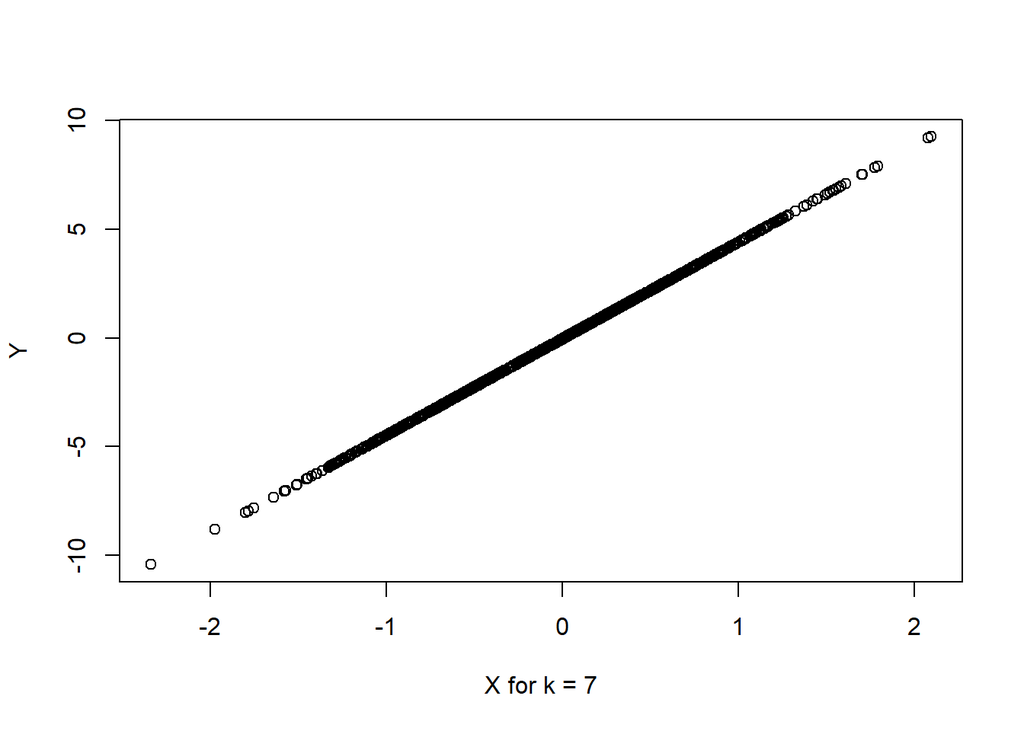

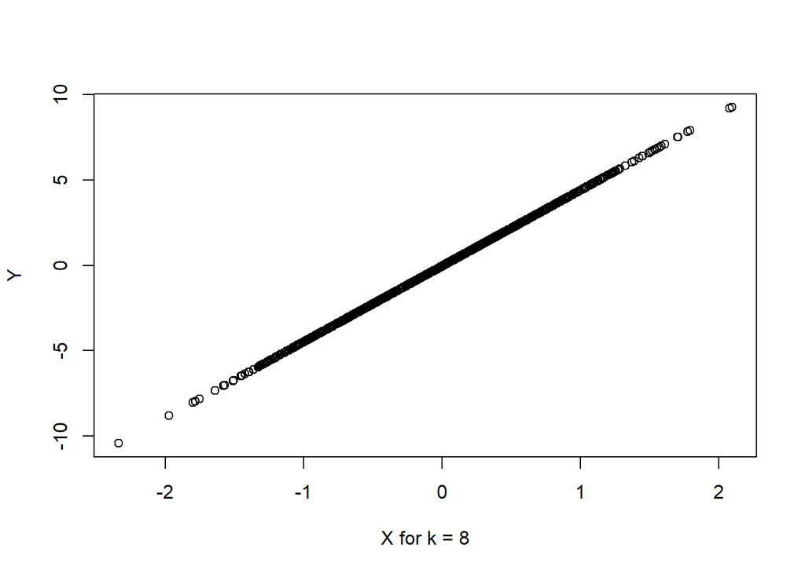

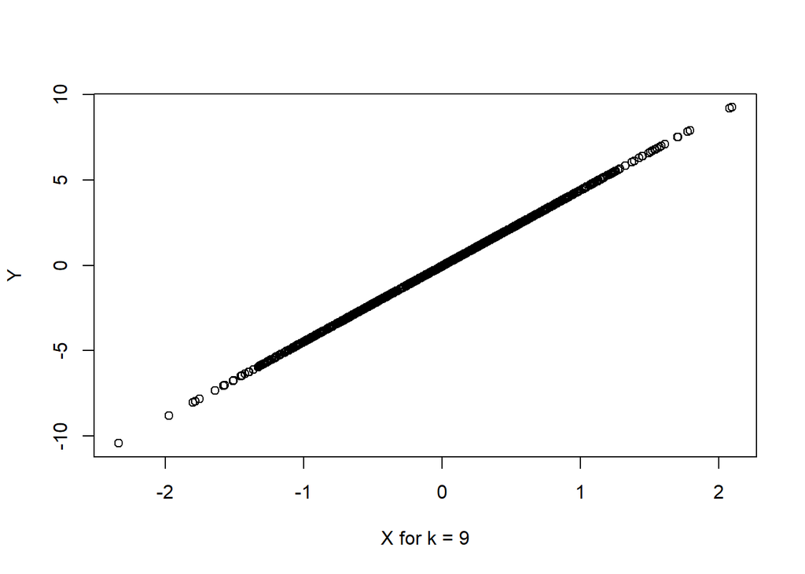

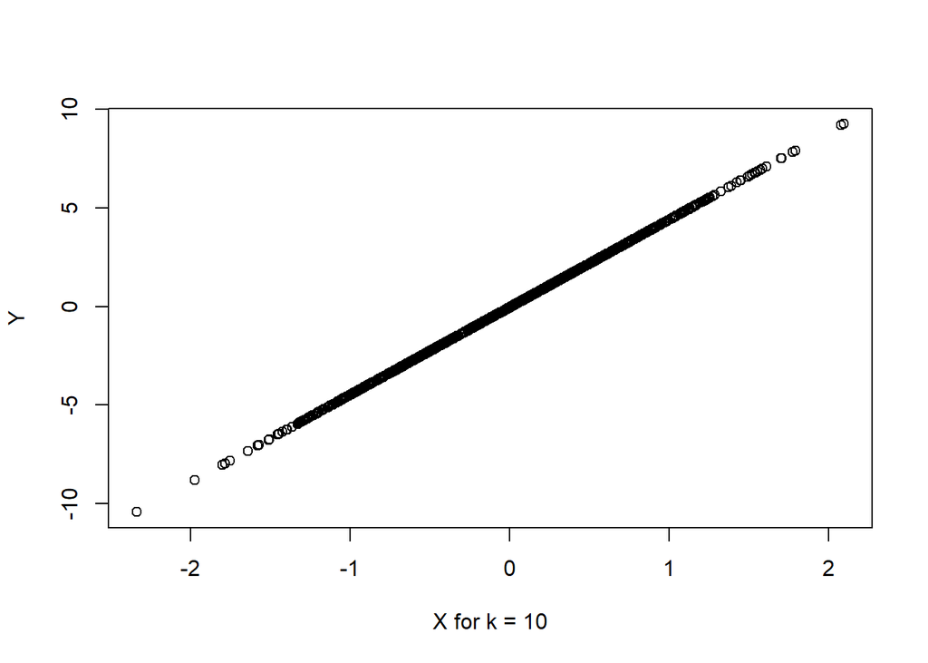

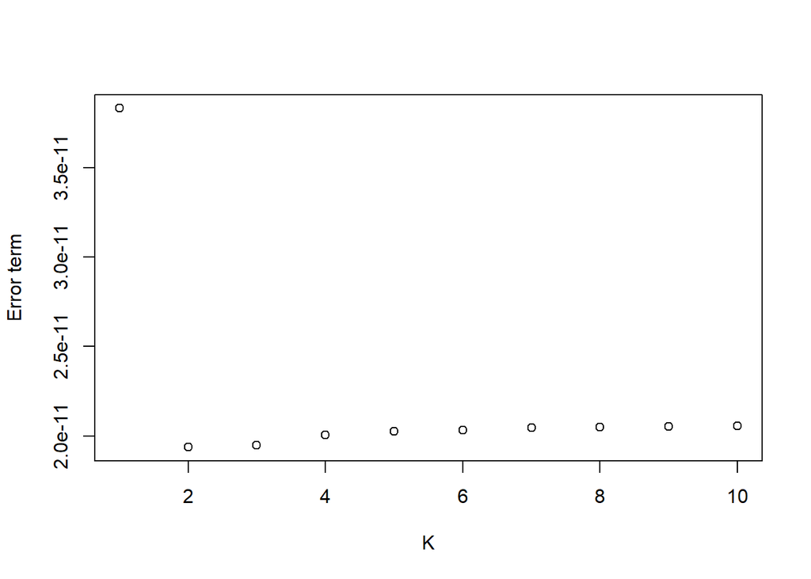

**Below is the plot of the first eigenvector, followed by a plot of the first PC score.**

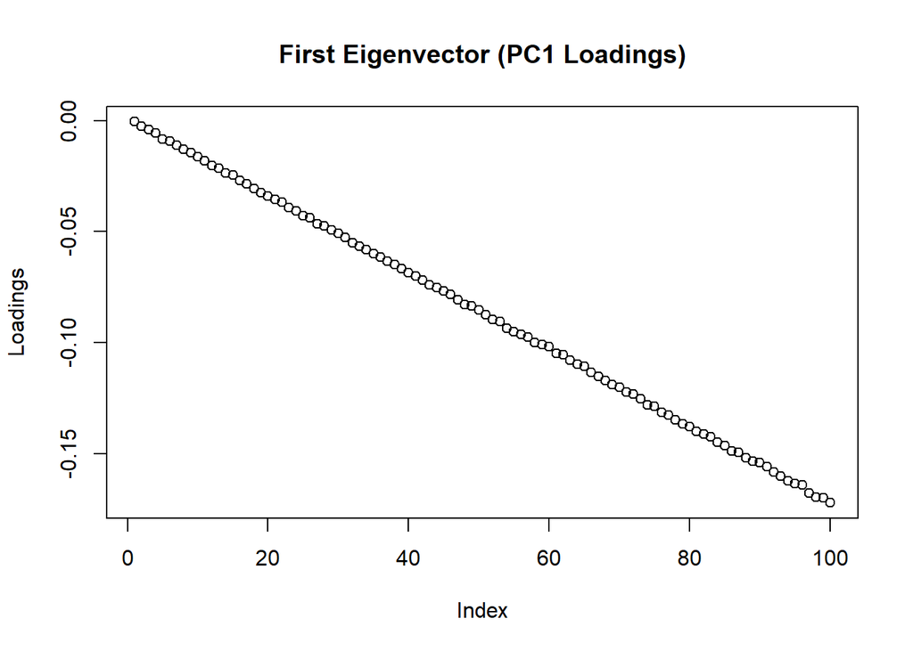

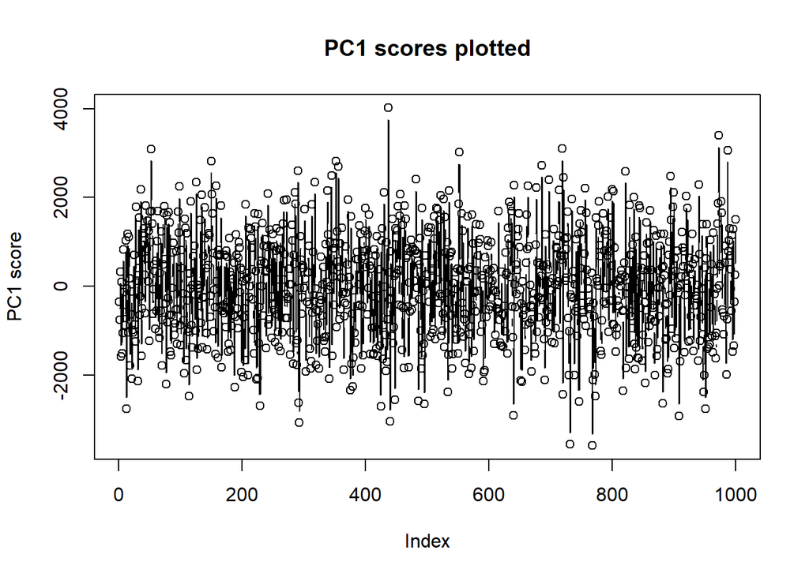

**Similar to the first image, the PC scores furthest away from zero are the features that are most compatible with the new “pattern” the PCA algorithm determined. For eigenvectors, the scores determine how much a feature contributes to the principal component itself.**

## Image 3

**Here are the rank approximations for the third image, as well as the plot of error terms and k values.**

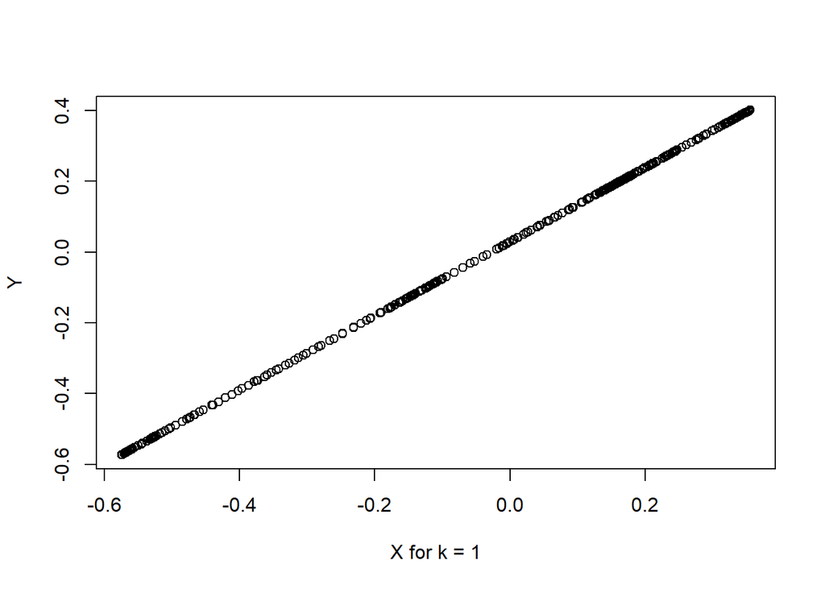

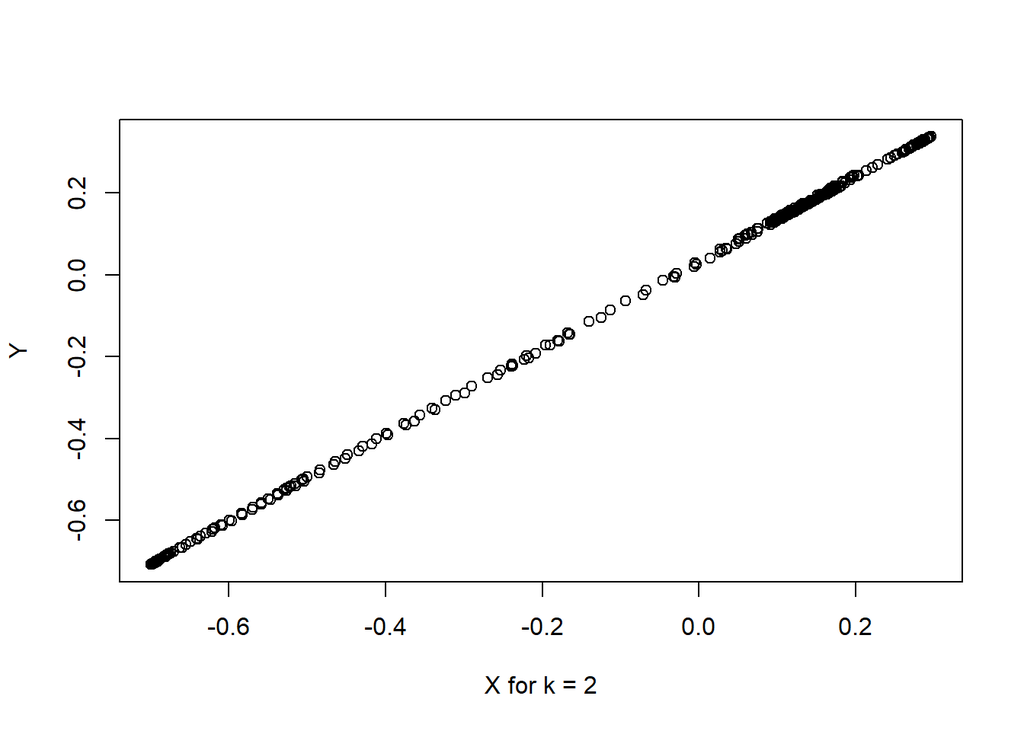

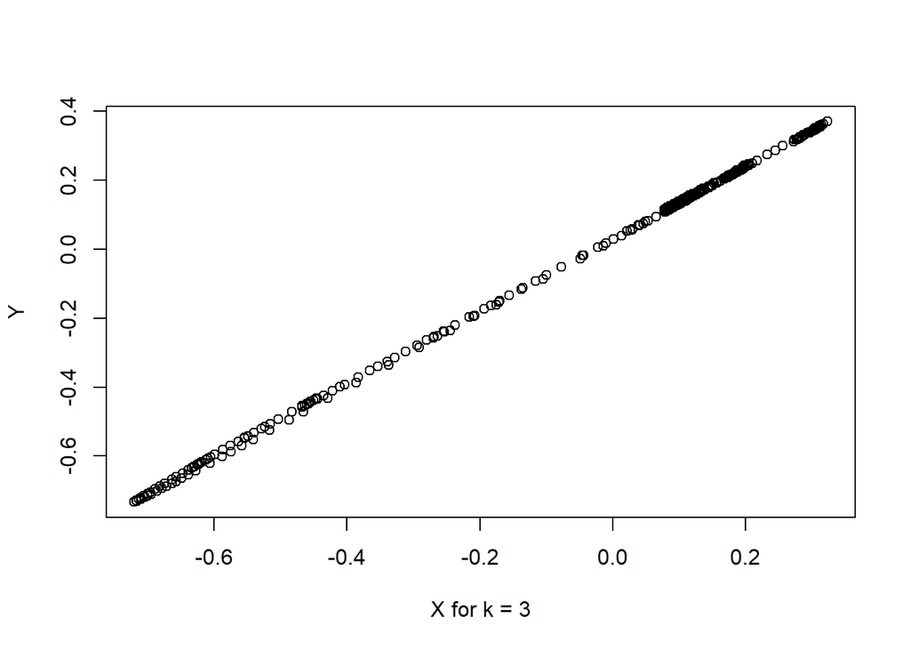

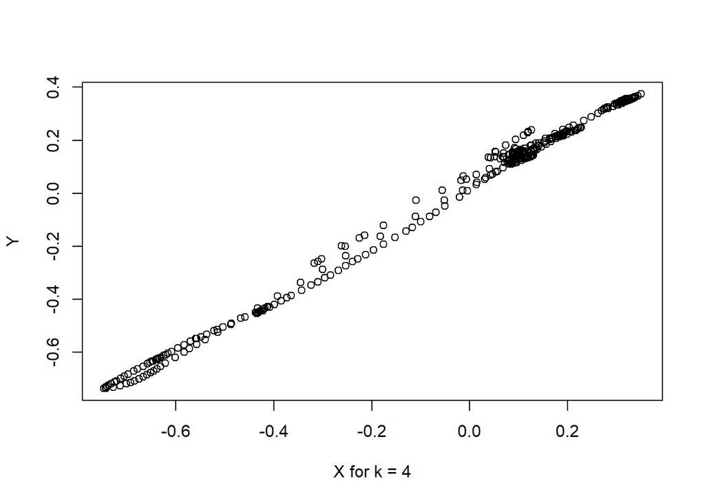